# Practical Machine Learning - Assignment

Nikolaos Lamprou

January 23, 2015

## Introduction

Six young health participants were asked to perform one set of 10 repetitions of the Unilateral Dumbbell Biceps Curl in five different fashions: exactly according to the specification (Class A), throwing the elbows to the front (Class B), lifting the dumbbell only halfway (Class C), lowering the dumbbell only halfway (Class D) and throwing the hips to the front (Class E).

The goal of this work is to build a model to predict the manner in which the exercise is performed using data from accelerometers on the belt, forearm, arm, and dumbell of the 6 participants.

## Getting and Cleaning Data

The data for this project come from this source: http://groupware.les.inf.puc-rio.br/har

The training data for this project are available here: https://d396qusza40orc.cloudfront.net/predmachlearn/pml-training.csv

The test data are available here: https://d396qusza40orc.cloudfront.net/predmachlearn/pml-testing.csv

The manner in which the exercise is performed is the “classe” variable.

The data are loaded into memory and missing or erroneous values are replaced by NAs to make cleaning the data easier.

```r
raw.training <- read.csv("/Users/nikolaoslamprou/Desktop/Data Science/Practical Machine Learning/pml-training.csv",
                         na.strings=c("#DIV/0!", "","NA"))

raw.testing <- read.csv("/Users/nikolaoslamprou/Desktop/Data Science/Practical Machine Learning/pml-testing.csv",
                        na.strings=c("#DIV/0!", "","NA"))
```

The dimensions of the raw datasets are:

```r
dim(raw.training)
```

```
## [1] 19622   160
```

```r
dim(raw.testing)
```

```
## [1]  20 160
```

A large number of columns have missing/erroneous values. For the purpose of better prediction accuracy and the reduction of the number of predictors, only columns without NAs are selected.

```r
clean.training<-raw.training[,colSums(is.na(raw.training)) == 0]
clean.testing <-raw.testing[,colSums(is.na(raw.testing)) == 0]
```

Variables in columns 1 to 7 (such as rownumber, user_name, timestamps etc.) are irrelevant to the classifictation and are removed.

```r
final.training <- clean.training[,-c(1:7)]
final.testing <- clean.testing[,-c(1:7)]
```

The dimension of the final (cleaned) datasets we will be using are:

```r
dim(final.training)
```

```
## [1] 19622    53
```

```r
dim(final.testing)
```

```
## [1] 20 53
```

## Data Slicing and Cross-validation

1 fold cross-validation will be performed by subsampling our final.training data set randomly without replacement into 2 subsamples: training.tr data (70% of the original final.training data set) and training.cv data (30%).

Two models are fitted on the training.tr data set, and tested on the training.cv dataset. The out of sample is then estimated.

Set seed (123) for reproducability of results.

```r
set.seed(123)
```

```r
library(caret)
inTrain <- createDataPartition(y=final.training$classe, p=0.7, list=FALSE)
training.tr <- final.training[inTrain, ]
training.cv <- final.training[-inTrain, ]
dim(training.tr)
```

```
## [1] 13737    53
```

```r
dim(training.cv)
```

```
## [1] 5885   53
```

## Building and Evaluating Predictive Models

Load necessary libraries

```r
library(caret)
library(rpart)
library(rpart.plot)
library(rattle)
library(randomForest)
library(ggplot2)
library(gridExtra)
```

### Classification Tree

```r
modelTree <- rpart(classe ~ ., data=training.tr, method="class")
confusionMatrix(training.cv$classe,predict(modelTree,training.cv,type="class"))
```

```
## Confusion Matrix and Statistics
##
##           Reference
## Prediction    A    B    C    D    E
##          A 1424   26   33  167   24
##          B  184  667  107  106   75
##          C   52   54  701  193   26
##          D   56   48   53  735   72
##          E   25   70   52  157  778
##
## Overall Statistics
##
##                Accuracy : 0.732
##                  95% CI : (0.72, 0.743)
##     No Information Rate : 0.296
##     P-Value [Acc > NIR] : <2e-16
##
##                   Kappa : 0.661
##  Mcnemar's Test P-Value : <2e-16
##
## Statistics by Class:
##
##                      Class: A Class: B Class: C Class: D Class: E
## Sensitivity             0.818    0.771    0.741    0.541    0.798
## Specificity             0.940    0.906    0.934    0.949    0.938
## Pos Pred Value          0.851    0.586    0.683    0.762    0.719
## Neg Pred Value          0.925    0.958    0.950    0.873    0.959
## Prevalence              0.296    0.147    0.161    0.231    0.166
## Detection Rate          0.242    0.113    0.119    0.125    0.132
## Detection Prevalence    0.284    0.194    0.174    0.164    0.184
## Balanced Accuracy       0.879    0.839    0.838    0.745    0.868
```

Plot the classification tree

[figure not shown]

```r
fancyRpartPlot(modelTree)
```

### Random Forest

```r
modelRF <- randomForest(classe ~ ., data=training.tr, method="class",ntree=100)
predictionRF <- predict(modelRF,training.cv,type="class")
confusionMatrix(training.cv$classe,predictionRF)
```

```
## Confusion Matrix and Statistics
##
##           Reference
## Prediction    A    B    C    D    E
##          A 1671    1    0    0    2
##          B    3 1135    1    0    0
##          C    0   13 1013    0    0
##          D    0    0   13  950    1
##          E    0    0    0    0 1082
##
## Overall Statistics
##
##                Accuracy : 0.994
##                  95% CI : (0.992, 0.996)
##     No Information Rate : 0.284
##     P-Value [Acc > NIR] : <2e-16
##
##                   Kappa : 0.993
##  Mcnemar's Test P-Value : NA
##
## Statistics by Class:
##
##                      Class: A Class: B Class: C Class: D Class: E
## Sensitivity             0.998    0.988    0.986    1.000    0.997
## Specificity             0.999    0.999    0.997    0.997    1.000
## Pos Pred Value          0.998    0.996    0.987    0.985    1.000
## Neg Pred Value          0.999    0.997    0.997    1.000    0.999
## Prevalence              0.284    0.195    0.175    0.161    0.184
## Detection Rate          0.284    0.193    0.172    0.161    0.184
## Detection Prevalence    0.284    0.194    0.174    0.164    0.184
## Balanced Accuracy       0.999    0.993    0.992    0.999    0.999
```

```r
modelRF
```

```
##
## Call:
##  randomForest(formula = classe ~ ., data = training.tr, method = "class",      ntree = 100)
##                Type of random forest: classification
##                      Number of trees: 100
## No. of variables tried at each split: 7
##
##         OOB estimate of  error rate: 0.66%
## Confusion matrix:
##      A    B    C    D    E class.error
## A 3902    2    0    0    2    0.001024
## B   13 2634    9    2    0    0.009029
## C    2   19 2368    7    0    0.011686
## D    0    0   23 2227    2    0.011101
## E    0    0    2    8 2515    0.003960
```

The plot below shows the importance of the each predictor in the classification process.

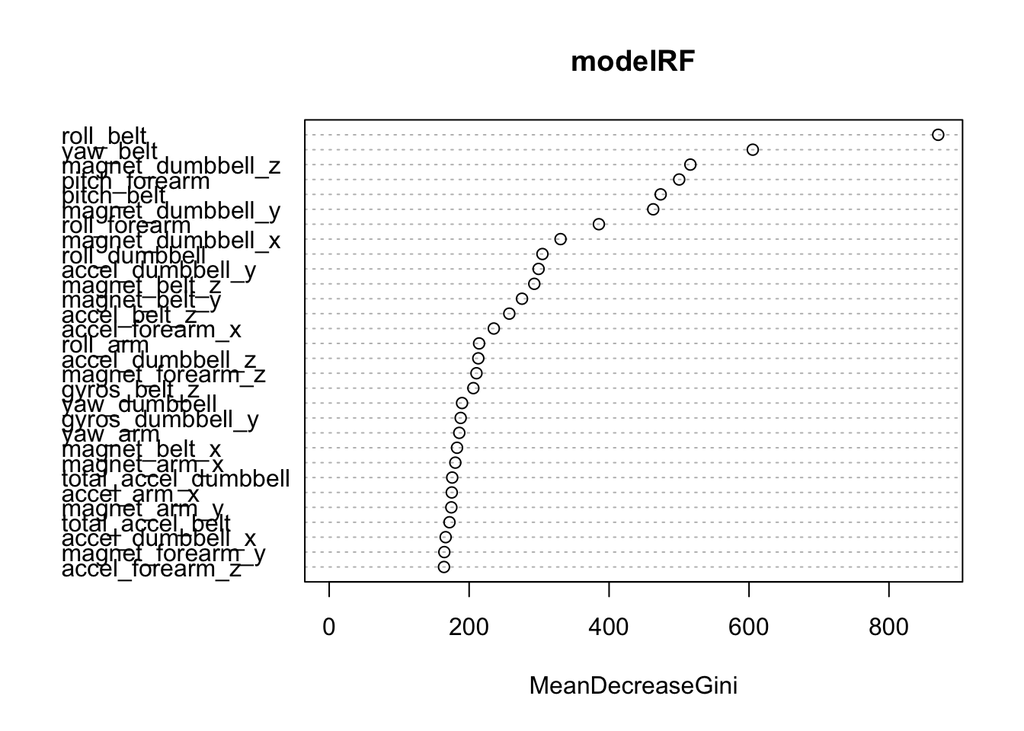

```r
varImpPlot(modelRF,)
```

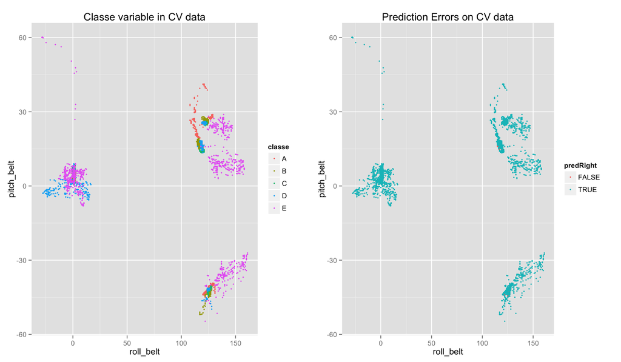

```r
training.cv$predRight <- predictionRF==training.cv$classe
q1 <- qplot(roll_belt,pitch_belt,colour=classe,data=training.cv,
            main="Classe variable in CV data",size=I(0.9))
q2 <- qplot(roll_belt,pitch_belt,colour=predRight,data=training.cv,
            main="Prediction Errors on CV data",size=I(0.9))

grid.arrange(q1, q2, ncol=2)
```

## Estimate Out-of-sample Error

The expected out-of-sample error corresponds to the expected number of missclassified observations/total observations in the Test data set. This is equivalent to the quantity: 1 - accuracy found from the cross-validation data set.

### 5-Fold Cross Validation

Set number of folds to 5 and create the resampling indicies.

```r
k <- 5
inTrain <- createDataPartition(y=final.training$classe,times=k,p=0.7,list=F)
```

Perform fit and calculate Out-of-sample error for each resampling.

```r
OOSE <- data.frame()
for (i in 1:k){
  trainingset <- final.training[inTrain[,i],]
  testset <- final.training[-inTrain[,i],]

  modelRF.cv <- randomForest(trainingset$classe ~ ., data = trainingset,method="class",
                             ntree = 100)

  Predicted <- predict(modelRF.cv, testset,type="class")
  Actual <- testset$classe
  Result <- data.frame(Predicted=Predicted,Actual=Actual)

  tempOOSE <- data.frame(oose=nrow(Result[Result$Predicted != Result$Actual,])/nrow(Result))
  OOSE <- rbind(OOSE,tempOOSE)
}
```

We calculate the average of the out-of-sample errors.

```r
mean(OOSE$oose)
```

```
## [1] 0.005234
```

The out-of-sample error estimate is of the same order as before at 0.005234 or 0.52%.

## Predictions for Submission

The random forest model is the most accurate and is used to predict on the testing set for submission.

```r
pml_write_files = function(x){
  n = length(x)
  for(i in 1:n){
    filename = paste0("/Users/nikolaoslamprou/Desktop/Data Science/Practical Machine Learning/Answers/problem_id_",i,".txt")
    write.table(x[i],file=filename,quote=FALSE,row.names=FALSE,col.names=FALSE)
  }
}

predict(modelRF,final.testing,type="class")
```

```
##  1  2  3  4  5  6  7  8  9 10 11 12 13 14 15 16 17 18 19 20
##  B  A  B  A  A  E  D  B  A  A  B  C  B  A  E  E  A  B  B  B
## Levels: A B C D E
```

```r
#pml_write_files(predict(modelRF,final.testing,type="class"))
```